# Lab4_Megroe

Megan

2025-11-18

## Lyric Sentiment Using songs by Kali Uchis

```r
library(tidytext)
library(textdata)
library(tidyverse)
#get_sentiments("afinn")
```

First we will load in our CSV file that contains the lyrics from three songs out of Kali Uchis’s album “Sincerely”.

```r
Sincerely <- read.csv("Kali_Uchis_Lyrics - Sheet1.csv")
```

Here we look at the words with an anger score from the NRC lexicon. With this procedure we can answer what are the most common negative words in the three songs we chose from “Sincerely”. Below we get a look at what words are considered to have an “anger” sentiment.

```r
nrc_anger <- get_sentiments("nrc") %>%
  filter(sentiment == "anger")
nrc_anger
```

```
## # A tibble: 1,245 × 2
##    word        sentiment
##    <chr>       <chr>
##  1 abandoned   anger
##  2 abandonment anger
##  3 abhor       anger
##  4 abhorrent   anger
##  5 abolish     anger
##  6 abomination anger
##  7 abuse       anger
##  8 accursed    anger
##  9 accusation  anger
## 10 accused     anger
## # ℹ 1,235 more rows
```

```r
library(stringr)
## we need to make sure that the lyrics are characters
Sincerely$lyrics <- as.character(Sincerely$lyrics)

tidy_song <- Sincerely %>%
  group_by(track_title) %>%
  ungroup() %>%
  unnest_tokens(word,lyrics)
```

Now we connect the nrc lexicon with those of the song, and a bit unsurprisingly there are not that many angry words.

```r
tidy_song %>%
  filter(track_title == "Sunshine & Rain")%>%
  inner_join(nrc_anger) %>%
  count(word, sort = TRUE)
```

```
## # A tibble: 4 × 2
##   word                 n
##   <chr>            <int>
## 1 damage               1
## 2 deranged             1
## 3 misunderstanding     1
## 4 storm                1
```

The zong Breeze! by Kali Uchis is a happy, joyful song, so this result is not surprising.

```r
tidy_song %>%
  filter(track_title == "Breeze!")%>%
  inner_join(nrc_anger) %>%
  count(word, sort = TRUE)
```

```
## # A tibble: 1 × 2
##   word      n
##   <chr> <int>
## 1 fear      1
```

```r
tidy_song %>%
  filter(track_title == "It's Just Us")%>%
  inner_join(nrc_anger) %>%
  count(word, sort = TRUE)
```

```
## # A tibble: 5 × 2
##   word      n
##   <chr> <int>
## 1 evil      1
## 2 money     1
## 3 rob       1
## 4 thief     1
## 5 words     1
```

Now let’s assess the sentiment of the different song lines in the song of the three songs we chose to look at. We apply a zero to the cases without a negative or positive word. Finally, we create a new variable that calculates the total sentiment (positive count minus negative).

```r
song_sentiment <- tidy_song %>%
  inner_join(get_sentiments("bing")) %>%
  count(track_title, index = line, sentiment) %>%
  spread(sentiment, n, fill = 0) %>%
  mutate(sentiment = positive - negative)
```

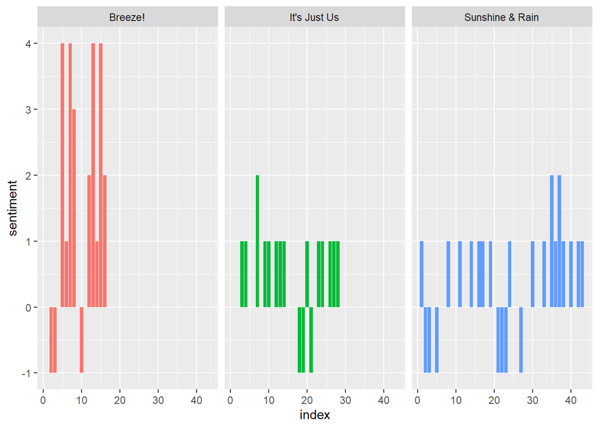

```r
ggplot(song_sentiment, aes(index, sentiment, fill = track_title)) +
  geom_col(show.legend = FALSE) +
  facet_wrap(~track_title)
```

## Looking deeper into Sentiment

In order: Sunshine & Rain, Breeze!, and lastly “It’s Just Us”.

```r
afinn <- tidy_song %>%
  filter(track_title == "Sunshine & Rain") %>%
  inner_join(get_sentiments("afinn")) %>%
  group_by(index = line) %>%
  summarise(sentiment = sum(value)) %>%
  mutate(method = "AFINN")
bing_and_nrc <- bind_rows(tidy_song %>%
                            filter(track_title == "Sunshine & Rain") %>%
                            inner_join(get_sentiments("bing")) %>%
                            mutate(method = "Bing et al."),
                          tidy_song %>%
                            filter(track_title == "Sunshine & Rain") %>%
                            inner_join(get_sentiments("nrc") %>%
                                         filter(sentiment %in% c("positive",
                                                                 "negative"))) %>%
                            mutate(method = "NRC")) %>%
  count(method, index = line, sentiment) %>%
  spread(sentiment, n, fill = 0) %>%
  mutate(sentiment = positive - negative)
```

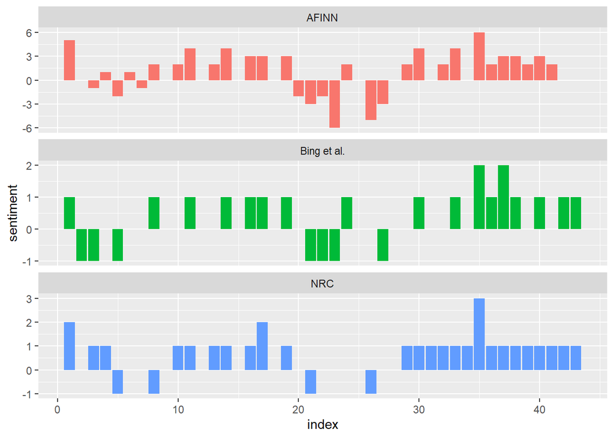

```r
bind_rows(afinn,
          bing_and_nrc) %>%
  ggplot(aes(index, sentiment, fill = method)) +
  geom_col(show.legend = FALSE) +
  facet_wrap(~method, ncol = 1, scales = "free_y")
```

```r
afinn <- tidy_song %>%
  filter(track_title == "Breeze!") %>%
  inner_join(get_sentiments("afinn")) %>%
  group_by(index = line) %>%
  summarise(sentiment = sum(value)) %>%
  mutate(method = "AFINN")
bing_and_nrc <- bind_rows(tidy_song %>%
                            filter(track_title == "Breeze!") %>%
                            inner_join(get_sentiments("bing")) %>%
                            mutate(method = "Bing et al."),
                          tidy_song %>%
                            filter(track_title == "Breeze!") %>%
                            inner_join(get_sentiments("nrc") %>%
                                         filter(sentiment %in% c("positive",
                                                                 "negative"))) %>%
                            mutate(method = "NRC")) %>%
  count(method, index = line, sentiment) %>%
  spread(sentiment, n, fill = 0) %>%
  mutate(sentiment = positive - negative)
```

We can now visualize the estimates of the net sentiment (positive - negative) for the song across each sentiment lexicon.

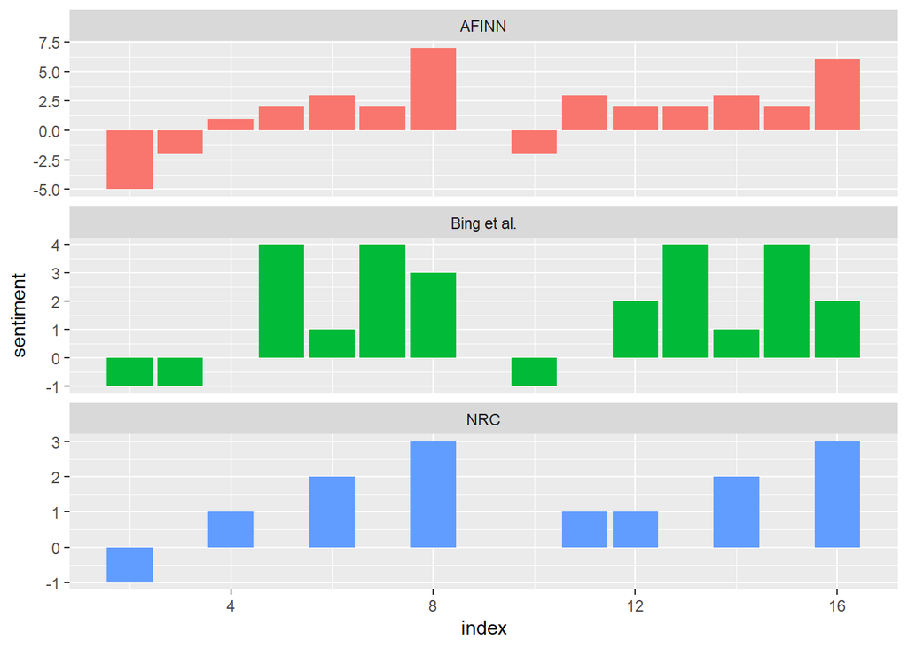

```r
bind_rows(afinn,
          bing_and_nrc) %>%
  ggplot(aes(index, sentiment, fill = method)) +
  geom_col(show.legend = FALSE) +
  facet_wrap(~method, ncol = 1, scales = "free_y")
```

```r
afinn <- tidy_song %>%
  filter(track_title == "It's Just Us") %>%
  inner_join(get_sentiments("afinn")) %>%
  group_by(index = line) %>%
  summarise(sentiment = sum(value)) %>%
  mutate(method = "AFINN")
bing_and_nrc <- bind_rows(tidy_song %>%
                            filter(track_title == "It's Just Us") %>%
                            inner_join(get_sentiments("bing")) %>%
                            mutate(method = "Bing et al."),
                          tidy_song %>%
                            filter(track_title == "It's Just Us") %>%
                            inner_join(get_sentiments("nrc") %>%
                                         filter(sentiment %in% c("positive",
                                                                 "negative"))) %>%
                            mutate(method = "NRC")) %>%
  count(method, index = line, sentiment) %>%
  spread(sentiment, n, fill = 0) %>%
  mutate(sentiment = positive - negative)
```

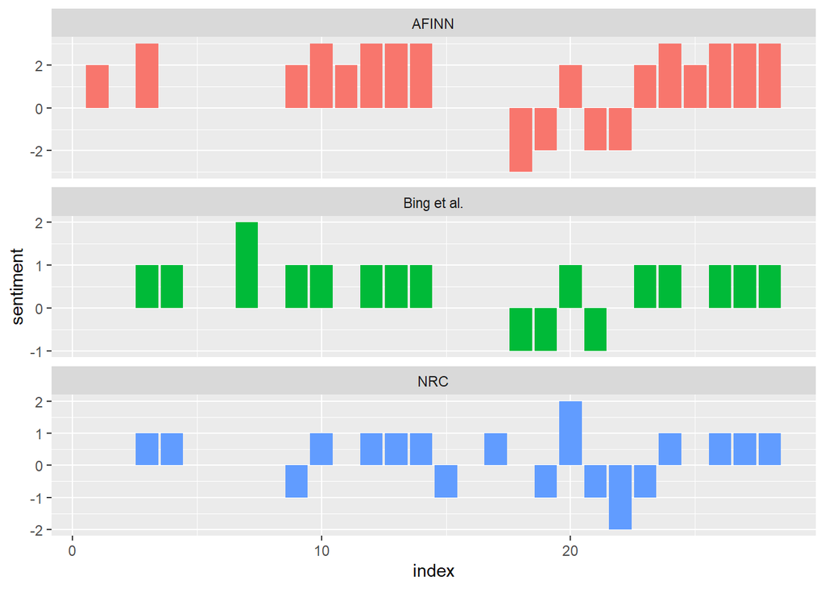

```r
bind_rows(afinn,
          bing_and_nrc) %>%
  ggplot(aes(index, sentiment, fill = method)) +
  geom_col(show.legend = FALSE) +
  facet_wrap(~method, ncol = 1, scales = "free_y")
```

There are differences in the result of the three different sentiment lexicons, but they have similar relative trajectories. We see similar positive and negative dips and peaks. To investigate these difference can look at the difference between positive and negative words across these lexicons.

```r
get_sentiments("nrc") %>%
     filter(sentiment %in% c("positive",
                             "negative")) %>%
  count(sentiment)
```

```
## # A tibble: 2 × 2
##   sentiment     n
##   <chr>     <int>
## 1 negative   3316
## 2 positive   2308
```

```r
get_sentiments("bing") %>%
  count(sentiment)
```

```
## # A tibble: 2 × 2
##   sentiment     n
##   <chr>     <int>
## 1 negative   4781
## 2 positive   2005
```

Both lexicons have more negative than positive words, but the ratio of negative to positive words is higher in the Bing lexicon than the NRC lexicon.

### Evaluating common positive and negative words

We can analyze word counts that contribute to each sentiment, and find out how much each word contributed to each sentiment.

```r
bing_word_counts <- tidy_song %>%
  inner_join(get_sentiments("bing")) %>%
  count(word, sentiment, sort = TRUE) %>%
  ungroup()
bing_word_counts
```

```
## # A tibble: 36 × 3
##    word         sentiment     n
##    <chr>        <chr>     <int>
##  1 love         positive     16
##  2 breeze       positive      8
##  3 easy         positive      8
##  4 heavenly     positive      4
##  5 perfect      positive      4
##  6 like         positive      3
##  7 catastrophic negative      2
##  8 fascinating  positive      2
##  9 good         positive      2
## 10 heaven       positive      2
## # ℹ 26 more rows
```

We can also visualize these difference using ggplot2.

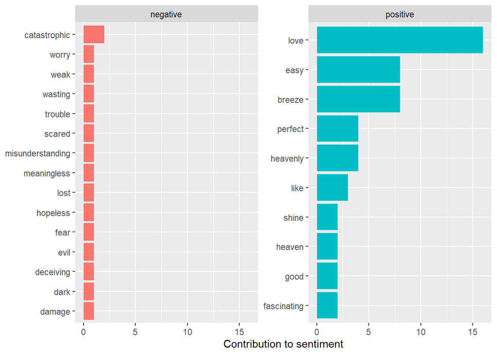

```r
bing_word_counts %>%
  group_by(sentiment) %>%
  top_n(10) %>%
  ungroup() %>%
  mutate(word = reorder(word, n)) %>%
  ggplot(aes(word, n, fill = sentiment)) +
  geom_col(show.legend = FALSE) +
  facet_wrap(~sentiment, scales = "free_y") +
  labs(y = "Contribution to sentiment",
       x = NULL) +
  coord_flip()
```

## Word clouds

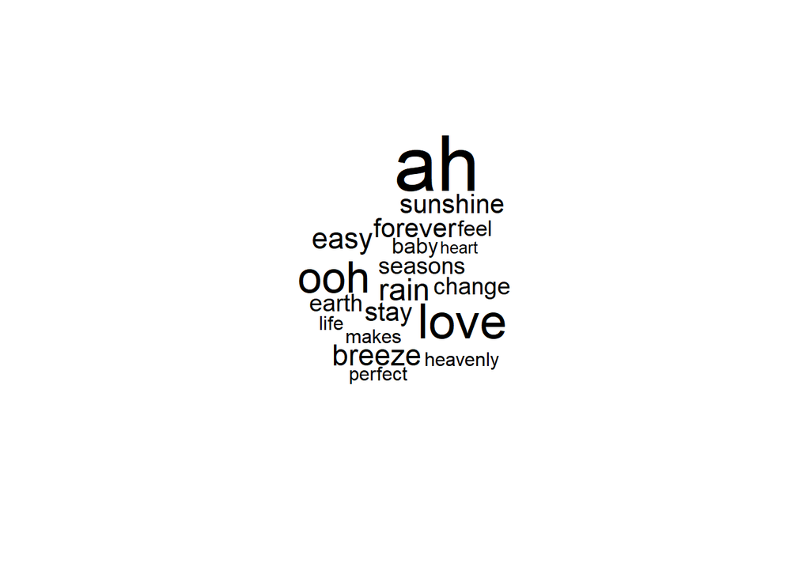

```r
library(wordcloud)
library(RColorBrewer)
tidy_song %>%
  anti_join(stop_words) %>%
  count(word) %>%
  with(wordcloud(word, n, max.words = 100))
```

```r
library(reshape2)
```

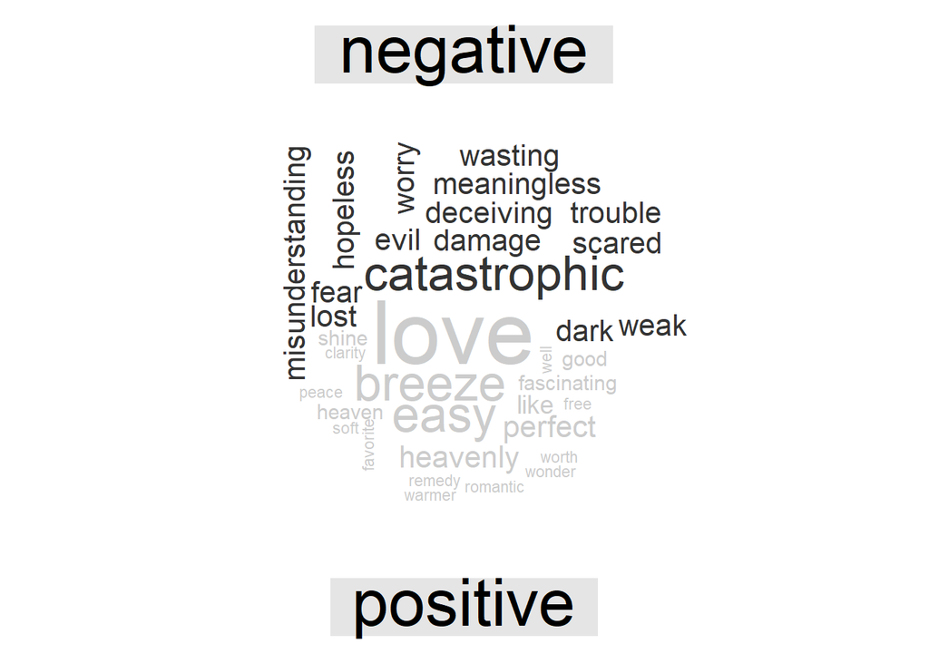

```r
tidy_song %>%
  inner_join(get_sentiments("bing")) %>%
  count(word, sentiment, sort = TRUE) %>%
  acast(word ~ sentiment, value.var = "n", fill = 0) %>%
  comparison.cloud(colors = c("gray20", "gray80"),
                   max.words = 100)
```

## Contextaulizing sentiment beyond just words

```r
library(sentimentr)
song_sentiment_sent <- Sincerely %>%
    get_sentences() %>%
    sentiment_by(by = c('track_title', 'line'))%>%
  as.data.frame()
```

Now we can plot the results to visualize the sentiment of the tracks for all three songs.

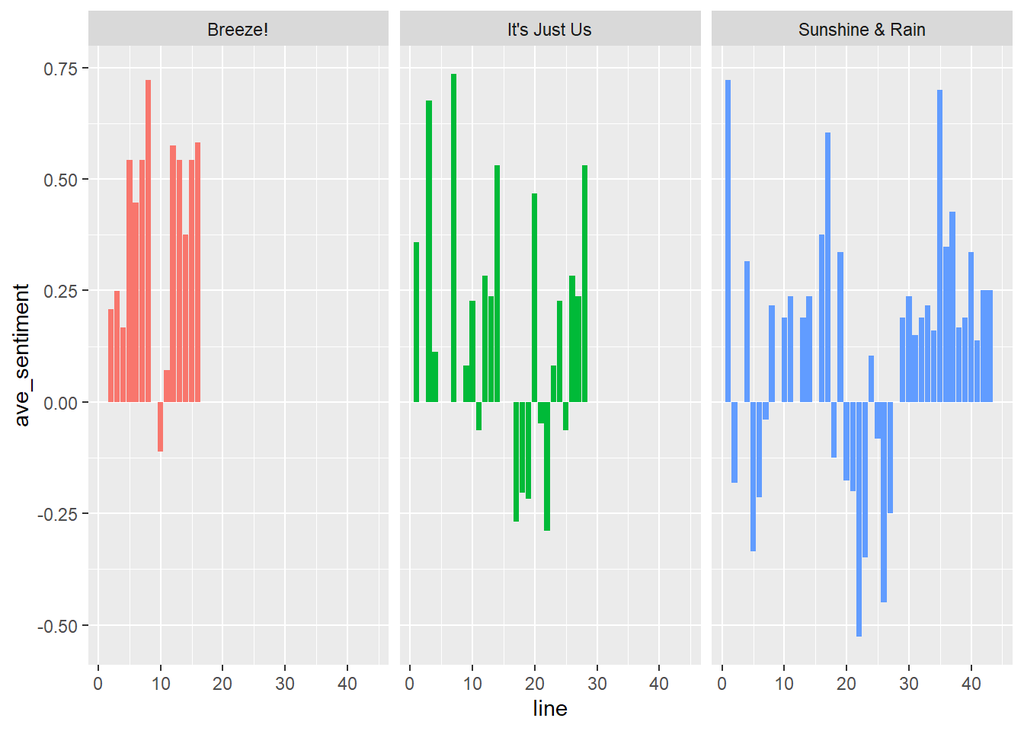

```r
ggplot(song_sentiment_sent, aes(line, ave_sentiment, fill = track_title)) +
  geom_col(show.legend = FALSE) +
  facet_wrap(~track_title)
```

```r
song_emotion_Sun <- Sincerely %>%
  filter(track_title == "Sunshine & Rain")%>%
  get_sentences() %>%
    emotion_by(by = c('track_title', 'line'))%>%
  as.data.frame()

head(song_emotion_Sun)
```

```
##       track_title line emotion_type word_count emotion_count sd ave_emotion
## 1 Sunshine & Rain    1        anger          3             0 NA   0.0000000
## 2 Sunshine & Rain    1 anticipation          3             1 NA   0.3333333
## 3 Sunshine & Rain    1      disgust          3             0 NA   0.0000000
## 4 Sunshine & Rain    1         fear          3             0 NA   0.0000000
## 5 Sunshine & Rain    1          joy          3             2 NA   0.6666667
## 6 Sunshine & Rain    1      sadness          3             0 NA   0.0000000
```

```r
song_emotion_Breeze <- Sincerely %>%
  filter(track_title == "Breeze!")%>%
  get_sentences() %>%
    emotion_by(by = c('track_title', 'line'))%>%
  as.data.frame

head(song_emotion_Breeze)
```

```
##   track_title line         emotion_type word_count emotion_count sd ave_emotion
## 1     Breeze!    1        anger_negated          9             0 NA           0
## 2     Breeze!    1         anticipation          9             0 NA           0
## 3     Breeze!    1 anticipation_negated          9             0 NA           0
## 4     Breeze!    1              disgust          9             0 NA           0
## 5     Breeze!    1                 fear          9             0 NA           0
## 6     Breeze!    1         fear_negated          9             0 NA           0
```

```r
song_emotion_Us <- Sincerely %>%
  filter(track_title == "It's Just Us")%>%
  get_sentences() %>%
    emotion_by(by = c('track_title', 'line'))%>%
  as.data.frame()

head(song_emotion_Us)
```

```
##    track_title line         emotion_type word_count emotion_count sd
## 1 It's Just Us    1                anger          5             0 NA
## 2 It's Just Us    1        anger_negated          5             0 NA
## 3 It's Just Us    1         anticipation          5             0 NA
## 4 It's Just Us    1 anticipation_negated          5             0 NA
## 5 It's Just Us    1              disgust          5             0 NA
## 6 It's Just Us    1      disgust_negated          5             0 NA
##   ave_emotion
## 1           0
## 2           0
## 3           0
## 4           0
## 5           0
## 6           0
```

### Sentiment Summary:

I was genuinely surprised at how well all these different components worked to show the sentiment of the three Kali Uchis songs that I chose to analyze. Although I chose “Breeze!” because it’s so clearly a joyous song, I chose the other two songs because although they seem happy and romantic on the surface, there are some undertones of sadness, grief, and uncertain. In the beginning, when I pulled out the “angry” words (lines 34-72), there were only a couple of words classified as anger in all three songs. Seeing this, I assumed that the sentiment of the two more complex songs “It’s Just Us” and “Sunshine & Rain” were not going to be captured. But as we moved on into the actual sentiment analysis, I was surprised to see that some of the more complex feelings began to show through. For instance, when graph the sentiments of the song (line 84 and 285), the complexity is somewhat visualized for both of those songs, while Breeze! is clearly a positive sentiment. Then, when we look at the word cloud graphic (line 256), wecan begin to see the complexities of the words that are clearly meant to invoke negative feelings verse positive ones.

## AI for text classification and sentiment

Finally, we will conduct a structured, AI-based analysis of a TikTok dataset. The data include climate-related TikToks for which we aim to study not just sentiment, but also categories such as climate pessimism. While we can access an AI API from R, it requires a paid license. For accessibility, I designed this exercise in UMich ChatGPT, but it works similarly with other AIs. It does require copying and pasting prompts into the interface, and we are not able to fine-tune the model. In essence, we use a zero-shot model to classify content and return sentiment in a structured format (though a few examples help “nudge” performance and can be tweaked).

```r
tiktok<-read.csv("TikTok_Pessimism.csv")
head(read.csv("TikTok_Pessimism.csv"))
```

```
##                                                                          url
## 1           https://www.tiktok.com/@1treellion.org/video/7376717572718497070
## 2                 https://www.tiktok.com/@_jefffy_/video/7449862319170964766
## 3 https://www.tiktok.com/@achilles_de_anthropocene/video/7387169037375196462
## 4        https://www.tiktok.com/@americanlangster0/video/7392646542466747679
## 5             https://www.tiktok.com/@andrewwookey/video/7338352473456921899
## 6        https://www.tiktok.com/@asherthealchemist/video/7382352961080544542
##                                                                                                                                                                                                                                                                                                          …
## 1                                                                                                                                                                                                                                                                                                        …
## 2                                                                                                                                                                                                                                                                                                        …
## 3 When you give corporations freedom from regulation, you give them the choice between doing what is best for humans and doing what is best for profit, and there is always going to be one of those that they choose. I made a video a while ago about the growing wealth inequality in America and this…
## 4                                                                                                                                                                                                                                                                                                        …
## 5                                                                                                                                                                                                                                                                                                        …
## 6                                                                                                                                                                                                                                                                                                        …
```

```
System: You are a rater that classifies short statements about climate change using a fixed schema. Follow the instructions exactly and return valid JSON only.

User: Classify the following statement.

Schema (JSON):

{
  "label": "A | B | C | D | E",
  "rationale": "brief reason citing key phrases",
  "evidence_spans": ["exact substrings that triggered the label"]
}

Definitions:
A = Accepts climate science …
B = Legitimate uncertainty …
C = Skeptical rhetoric …
D = Outright denial …
E = Off-topic/other …

Examples:
“CO₂ traps heat; we need to cut emissions.” → {"label":"A","rationale":"endorses greenhouse effect","evidence_spans":["cut emissions"]}
“I’m not sure how much is human-caused—any sources?” → {"label":"B","rationale":"good-faith uncertainty","evidence_spans":["any sources"]}
“It’s a hoax by scientists for grant money.” → {"label":"C","rationale":"conspiracy frame","evidence_spans":["hoax","grant money"]}
“Climate change isn’t real.” → {"label":"D","rationale":"explicit denial","evidence_spans":["isn’t real"]}
```

Now, copy one short statement or sentence from the TikTok dataset (from the text column in your CSV) and paste it directly into the UMich ChatGPT text box after the structured prompt. It should return a response in JSON format, similar to this:

```
{"label":"A","sentiment":"positive","rationale":"supports climate science and highlights positive impacts of urban tree cover on environment and health","evidence_spans":["reduce the urban heat island effect","tree coverage is vital in sheltering communities from heat waves","helps to reduce heat-related illnesses and mortality","reduce erosion and filter rainwater","reduce flooding"]}
```

Summary: I submitted this quote: “What about the freedom to breathe clean air, drink safe water, and to not die from extreme heat? Prohibiting expenditures or efforts to promote, advocate, or plan for reducing or replacing vehicle travel with walking, biking, or public transit has implications for our air quality as well as for mobility of non-drivers. Not everyone in our communities does drive or can drive. And of course, cleaning up our air improves and saves lives. Actions to hinder that have real impacts on your constituents.” The classification that Umich GPT gave this quote was: “label”: “A”, “rationale”: “supports actions to improve air quality and save lives, links mobility and climate action”, “evidence_spans”: [ “freedom to breathe clean air”, “cleaning up our air improves and saves lives”, “actions to hinder that have real impacts”.

Overall, I think that the AI was able to interpret the quote correctly. I had thought that it may have only looked at the individual words and may have gotten tripped up, but in the evidence spans section of their response, they looked at groups of words. I think this helped to reach the right conclusion. I will say that there is not much that the AI did in terms of describing the sentiment for the quote. This quote, to me, is clearly charged and passionate, but I am not confident that the AI picked that up.